# Solution notes to assignment Week 6 - Mixed Effect Models

Torbjørn Ergon

2025-03-09

Solution notes are inserted in green boxes (like this one) in the original assignment text below.

# 1 Assignment: Student morphometrics

This assignment is based on the same student measurement data set that you have been working with earlier, but instead of mean measurements per individual these data also include the repeated measurements.

First, load the dataset:

```r
load("students.RData")
summary(students)
```

```
##       ID                Sex      Measurement_number       Eye_colour
##  Length:222         female:144   Min.   :1          blue       :139
##  Class :character   male  : 78   1st Qu.:1          brown      : 51
##  Mode  :character                Median :2          grey       :  9
##                                  Mean   :2          hazel      :  9
##                                  3rd Qu.:3          blue-grey  :  9
##                                  Max.   :3          light-brown:  3
##                                                     (Other)    :  2
##  Hair_colour     Height      Length_of_right_underarm
##  dark :142   Min.   :152.0   Min.   :20.20
##  light: 74   1st Qu.:164.0   1st Qu.:24.30
##  NA's :  6   Median :170.2   Median :25.50
##              Mean   :171.6   Mean   :25.88
##              3rd Qu.:179.9   3rd Qu.:27.27
##              Max.   :193.9   Max.   :32.30
##
##  Length_of_right_underarm_and_hand Length_of_right_foot Length_of_left_foot
##  Min.   :24.60                     Min.   :20.50        Min.   :20.30
##  1st Qu.:41.62                     1st Qu.:23.02        1st Qu.:23.00
##  Median :43.80                     Median :24.35        Median :24.40
##  Mean   :43.69                     Mean   :24.51        Mean   :24.56
##  3rd Qu.:45.67                     3rd Qu.:25.60        3rd Qu.:25.90
##  Max.   :51.00                     Max.   :29.40        Max.   :28.90
##                                                         NA's   :1
##  Neck_circumference Height_of_mother Height_of_father    Comments
##  Min.   :23.00      Min.   :156.0    Min.   :167.0           :144
##  1st Qu.:31.12      1st Qu.:163.0    1st Qu.:174.7    g1p1   :  3
##  Median :33.30      Median :168.0    Median :180.0    g1p2   :  3
##  Mean   :33.96      Mean   :166.8    Mean   :180.3    g1p3   :  3
##  3rd Qu.:37.00      3rd Qu.:171.0    3rd Qu.:185.2    g1p4   :  3
##  Max.   :43.00      Max.   :176.0    Max.   :193.0    (Other): 15
##                     NA's   :77       NA's   :75       NA's   : 51
##      Year
##  Length:222
##  Class :character
##  Mode  :character
##
##
##
##
```

1. Modify the code for making coloured scatter plots above to plot `Height` on the y-axis and `Height_of_father` on the x-axis. Colour the points by `Sex`and `ID` (one at a time) to get an overview of the data. TIP: Use `legend.position = "right"`, otherwise you won’t see the plot itself when using `col = ID`. You can also try to have `Height_of_mother` on the x-axis. Interpret what you see.

The original code for making the plot with `ggplot` is given in the assignment. We only show the plots with `Height_of_father` on the x-axis here:

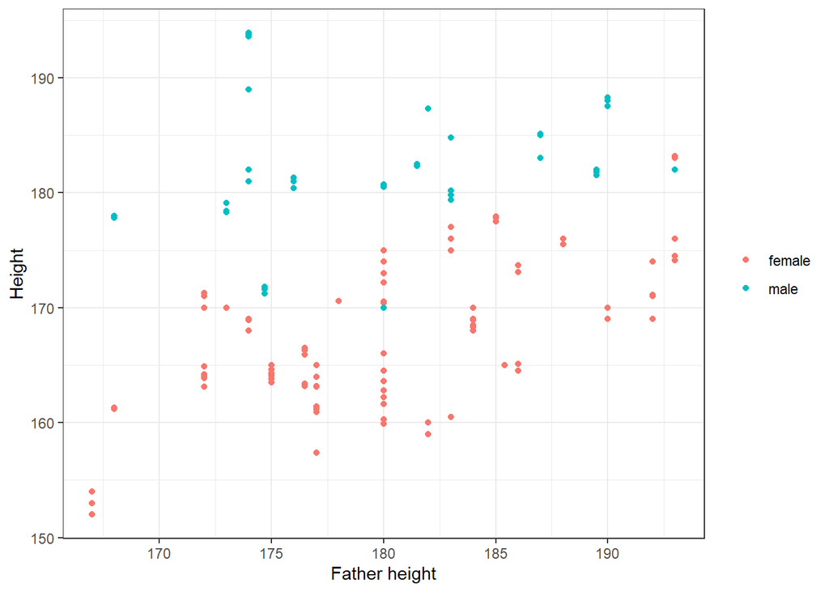

```r
library(ggplot2)

# Colour by 'Sex'
ggplot(students, aes(x = Height_of_father, y = Height , col = Sex)) +
  geom_point() +
  theme_bw()+
   labs(x="Father height", y="Height") +
  theme(legend.position = "right", legend.title = element_blank())
```

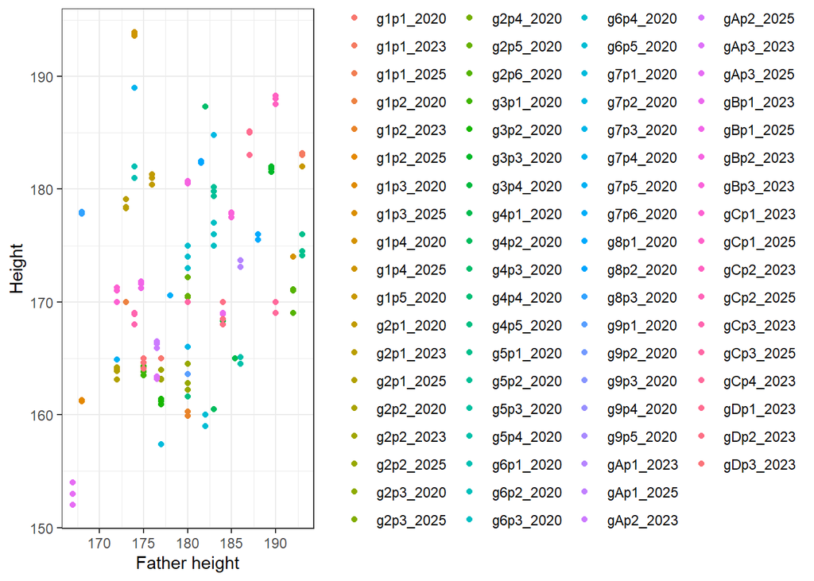

```r
# Colour by ID
ggplot(students, aes(x = Height_of_father, y = Height , col = ID)) +
  geom_point() +
  theme_bw()+
   labs(x="Father height", y="Height") +
  theme(legend.position = "right", legend.title = element_blank())
```

Not surprisingly, males tend to be taller than females. For both sexes, there is a positive correlation between height and height of father (and height of mother). We also see that there are (mostly) three measurements per student. Some of the measurements are the same, and hence the points will sometimes be plotted on top of each other. Height of father (and mother) has not been measured (only reported by the students) and hence does not vary within students - i.e., `Height_of_father` is a group level covariate as it applies to each student and not each measurement.

2. Fit an ordinary linear model (using `lm()`) to the data to investigate how height is related to sex and parental height (include both `Height_of_mother` and `Height_of_father`, and for simplicity assume only additive effects), and interpret the results. Can you trust the confidence intervals from this model? Explain in your own words.

```r
fit_lm <- lm(Height ~ Sex + Height_of_mother + Height_of_father, data = students)
summary(fit_lm)
```

```
##
## Call:
## lm(formula = Height ~ Sex + Height_of_mother + Height_of_father,
##     data = students)
##
## Residuals:
##      Min       1Q   Median       3Q      Max
## -10.3579  -3.3962   0.0156   2.3577  12.8736
##
## Coefficients:
##                  Estimate Std. Error t value Pr(>|t|)
## (Intercept)      49.78941   17.07388   2.916 0.004129 **
## Sexmale          13.58288    0.88170  15.405  < 2e-16 ***
## Height_of_mother  0.27797    0.07972   3.487 0.000653 ***
## Height_of_father  0.39820    0.05832   6.828 2.42e-10 ***
## ---
## Signif. codes:  0 '***' 0.001 '**' 0.01 '*' 0.05 '.' 0.1 ' ' 1
##
## Residual standard error: 4.774 on 140 degrees of freedom
##   (78 observations deleted due to missingness)
## Multiple R-squared:  0.691,  Adjusted R-squared:  0.6843
## F-statistic: 104.3 on 3 and 140 DF,  p-value: < 2.2e-16
```

```r
confint(fit_lm)
```

```
##                       2.5 %     97.5 %
## (Intercept)      16.0334295 83.5453806
## Sexmale          11.8397099 15.3260509
## Height_of_mother  0.1203593  0.4355901
## Height_of_father  0.2828915  0.5135056
```

The estimates indicate that expected student height increases by 0.28 cm (standard error = 0.08 cm; 95% C.I.: 0.12 to 0.44 cm) when mother height increases by 1 cm, and by 0.40 cm (standard error = 0.06 cm; 95% C.I.: 0.28 to 0.51 cm) when father height increases by 1 cm. The lower 95% confidence interval for the effect of `Height_of_father` excludes the point estimate for the effect of `Height_of_mother`. Hence, if we trust these results, we may say we have some indication that fathers could have a stronger influence on the height of their offspring than mothers. However, we have here treated the three repeated measurements of each individual as if they were independent measurements in the data as a whole - i.e., as if the three repeated measurements were from three different *individuals* with mothers and fathers of the same height. This is a case of pseudoreplication, and hence we cannot trust the standard errors (they are too small) or the confidence intervals (they are too narrow).

See next point for interpretation of `(Intercept)` and `Sexmale`.

3. Define and fit a mixed effects model with the same fixed effects that avoids pseudorepliation (hint: you need to specify a random effect on the intercept). Look at the summary and confidence intervals. What is the main difference between this and the previous model? What is the interpretation of each of the parameters in the model?

```r
library(lme4)
fit_lmer <- lmer(Height ~ Sex + Height_of_mother + Height_of_father + (1|ID), data = students)
summary(fit_lmer)
```

```
## Linear mixed model fit by REML ['lmerMod']
## Formula: Height ~ Sex + Height_of_mother + Height_of_father + (1 | ID)
##    Data: students
##
## REML criterion at convergence: 534.6
##
## Scaled residuals:
##      Min       1Q   Median       3Q      Max
## -2.44501 -0.45544  0.02676  0.35108  2.35599
##
## Random effects:
##  Groups   Name        Variance Std.Dev.
##  ID       (Intercept) 26.1420  5.1129
##  Residual              0.3118  0.5584
## Number of obs: 144, groups:  ID, 56
##
## Fixed effects:
##                  Estimate Std. Error t value
## (Intercept)       53.8088    29.9437   1.797
## Sexmale           14.4576     1.4987   9.646
## Height_of_mother   0.2705     0.1376   1.965
## Height_of_father   0.3799     0.1057   3.594
##
## Correlation of Fixed Effects:
##             (Intr) Sexmal Hght_f_m
## Sexmale      0.045
## Hght_f_mthr -0.770 -0.102
## Hght_f_fthr -0.644  0.029  0.008
```

```r
confint(fit_lmer)
```

```
##                         2.5 %      97.5 %
## .sig01            4.130885207   6.0071408
## .sigma            0.485061480   0.6523995
## (Intercept)      -3.726140727 111.3432937
## Sexmale          11.577825489  17.3373139
## Height_of_mother  0.006053874   0.5349362
## Height_of_father  0.176792651   0.5830440
```

**What is the main difference between this and the previous model?**

In this model we have accounted for the fact that there are differences in people’s height that can not be explained by their parents’ height. By including individual `ID` as a ramdom effects variable in the model, we now only assume that the three repeated measurements of each individual are independent conditional on the individual that is being measured, and not that they are independent in the data as a whole. As a result the standard errors of the fixed effects parameters are larger and the confidence intervals are wider. We can now assume that the confidence intervals will cover the “true” vaules if we simulate data from the model, and refit the model, 95% of the times. In contrast, if we refit the model from point 2 to the simulated data, the confidence intervals will include the “true” value much less than 95% of the time (since this model is based on pseudoreplication).

4. [**Optional:** Heritability of a trait can be estimated as the slope in a linear model where the trait is the response variable and the mean trait of the parents as the predictor variable. Alternatively, one can use the trait of *one* parent as the predictor variable and multiply the slope by 2 to get an estimate of heritability. Since there is a sex-difference on Height, we can define the trait as how much the height of an individual differs from the sex-specific mean height (i.e., subtract the mean height of females from all female heights, and the mean height of males from all males). Fit appropriate mixed-models to estimate heritability of height. You may also try to estimate different heritabilities for males and females.]

First, we compute the trait value (as defined above) for each student, and the mean trait value of their parents:

```r
students$trait[students$Sex == "female"] <- students$Height[students$Sex == "female"] - mean(students$Height[students$Sex == "female"])

students$trait[students$Sex == "male"] <- students$Height[students$Sex == "male"] - mean(students$Height[students$Sex == "male"])

students$mothers_st <- students$Height_of_mother - mean(students$Height_of_mother, na.rm = TRUE)

students$father_st <- students$Height_of_father - mean(students$Height_of_father, na.rm = TRUE)

students$mid_parent <- (students$mothers_st + students$father_st)/2
```

Then we fit a mixed model (to account for repeated mesurements) for the trait with mean trait value of their parents as the predictor variable:

```r
fit_parent_offspring <- lmer(trait ~ mid_parent + (1|ID), data = students)
summary(fit_parent_offspring)
```

```
## Linear mixed model fit by REML ['lmerMod']
## Formula: trait ~ mid_parent + (1 | ID)
##    Data: students
##
## REML criterion at convergence: 534.7
##
## Scaled residuals:
##      Min       1Q   Median       3Q      Max
## -2.43716 -0.45746  0.02566  0.35245  2.35539
##
## Random effects:
##  Groups   Name        Variance Std.Dev.
##  ID       (Intercept) 25.4308  5.0429
##  Residual              0.3118  0.5584
## Number of obs: 144, groups:  ID, 56
##
## Fixed effects:
##             Estimate Std. Error t value
## (Intercept)   0.9728     0.6759   1.439
## mid_parent    0.6764     0.1659   4.077
##
## Correlation of Fixed Effects:
##            (Intr)
## mid_parent -0.007
```

```r
confint(fit_parent_offspring)
```

```
##                  2.5 %    97.5 %
## .sig01       4.1527421 6.0384557
## .sigma       0.4850439 0.6523582
## (Intercept) -0.3507180 2.2961111
## mid_parent   0.3515250 1.0012885
```

Based on this, the heritability of body height is 0.68 (95% C.I.: 0.35 to 1.00). Note that although heritability can never be larger than 1 (100%), the estimates (and in particular upper the confidence limits) can become larger than 1 in this model. This is because there is no constraint in the model that forces the parameter (the slope) to be between 0 and 1. With little data, we can also get estimates lower than 0 (which also does not make sense biologically).